# In this project I analyzed the effects of the COVID-19 outbreak on certain indexes in countries affected most by the outbreak.

### (Scroll to the bottom if you don't care about the actual code)

### First I imported the necessary libraries including the yahoo finance API which was used to retrieve some of the data.

```python
# Import necessary utilities

import numpy as np
import pandas as pd
import matplotlib.pyplot as plt
import seaborn as sns
import yfinance as yf
```

### The next step was then to clean the data by isolating to the dates available in our COVID-19 dataset, and averaging the values.

```python
# Import Dow Jones Industrial Average Dataset beginning on January 1st, 2020 found here:
# https://finance.yahoo.com/quote/%5EDJI/history?period1=1577836800&period2=1584403200&interval=1d&filter=history&frequency=1d

DJI_DATASET = r"./Data/^DJI.csv"
disp_data = pd.read_csv(DJI_DATASET)
disp_data
```

|  | Date | Open | High | Low | Close | Adj Close | Volume |
| --- | --- | --- | --- | --- | --- | --- | --- |
| 0 | 2020-01-02 | 28638.970703 | 28872.800781 | 28627.769531 | 28868.800781 | 28868.800781 | 251820000 |
| 1 | 2020-01-03 | 28553.330078 | 28716.310547 | 28500.359375 | 28634.880859 | 28634.880859 | 239590000 |
| 2 | 2020-01-06 | 28465.500000 | 28708.019531 | 28418.630859 | 28703.380859 | 28703.380859 | 252760000 |
| 3 | 2020-01-07 | 28639.179688 | 28685.500000 | 28565.279297 | 28583.679688 | 28583.679688 | 258900000 |
| 4 | 2020-01-08 | 28556.140625 | 28866.179688 | 28522.509766 | 28745.089844 | 28745.089844 | 291750000 |
| 5 | 2020-01-09 | 28851.970703 | 28988.009766 | 28844.310547 | 28956.900391 | 28956.900391 | 275060000 |
| 6 | 2020-01-10 | 28977.519531 | 29009.070313 | 28789.099609 | 28823.769531 | 28823.769531 | 237830000 |
| 7 | 2020-01-13 | 28869.009766 | 28909.910156 | 28819.429688 | 28907.050781 | 28907.050781 | 249830000 |
| 8 | 2020-01-14 | 28895.500000 | 29054.160156 | 28872.269531 | 28939.669922 | 28939.669922 | 287440000 |
| 9 | 2020-01-15 | 28901.800781 | 29127.589844 | 28897.349609 | 29030.220703 | 29030.220703 | 260270000 |
| 10 | 2020-01-16 | 29131.949219 | 29300.320313 | 29131.949219 | 29297.640625 | 29297.640625 | 252110000 |
| 11 | 2020-01-17 | 29313.310547 | 29373.619141 | 29289.910156 | 29348.099609 | 29348.099609 | 321820000 |
| 12 | 2020-01-21 | 29269.050781 | 29341.210938 | 29146.470703 | 29196.039063 | 29196.039063 | 320640000 |
| 13 | 2020-01-22 | 29263.630859 | 29320.199219 | 29172.259766 | 29186.269531 | 29186.269531 | 283440000 |
| 14 | 2020-01-23 | 29111.019531 | 29190.470703 | 28966.980469 | 29160.089844 | 29160.089844 | 307060000 |
| 15 | 2020-01-24 | 29230.390625 | 29288.789063 | 28843.310547 | 28989.730469 | 28989.730469 | 380010000 |
| 16 | 2020-01-27 | 28542.490234 | 28671.789063 | 28440.470703 | 28535.800781 | 28535.800781 | 337270000 |
| 17 | 2020-01-28 | 28594.279297 | 28823.230469 | 28575.750000 | 28722.849609 | 28722.849609 | 330140000 |
| 18 | 2020-01-29 | 28820.529297 | 28944.240234 | 28728.189453 | 28734.449219 | 28734.449219 | 302290000 |
| 19 | 2020-01-30 | 28640.160156 | 28879.710938 | 28489.759766 | 28859.439453 | 28859.439453 | 326850000 |
| 20 | 2020-01-31 | 28813.039063 | 28813.039063 | 28169.529297 | 28256.029297 | 28256.029297 | 403890000 |
| 21 | 2020-02-03 | 28319.650391 | 28630.390625 | 28319.650391 | 28399.810547 | 28399.810547 | 307910000 |
| 22 | 2020-02-04 | 28696.740234 | 28904.880859 | 28696.740234 | 28807.630859 | 28807.630859 | 332750000 |
| 23 | 2020-02-05 | 29048.730469 | 29308.890625 | 29000.849609 | 29290.849609 | 29290.849609 | 357540000 |
| 24 | 2020-02-06 | 29388.580078 | 29408.050781 | 29246.929688 | 29379.769531 | 29379.769531 | 263700000 |
| 25 | 2020-02-07 | 29286.919922 | 29286.919922 | 29056.980469 | 29102.509766 | 29102.509766 | 252860000 |
| 26 | 2020-02-10 | 28995.660156 | 29278.070313 | 28995.660156 | 29276.820313 | 29276.820313 | 250510000 |
| 27 | 2020-02-11 | 29390.710938 | 29415.390625 | 29210.470703 | 29276.339844 | 29276.339844 | 279540000 |
| 28 | 2020-02-12 | 29406.750000 | 29568.570313 | 29406.750000 | 29551.419922 | 29551.419922 | 309530000 |
| 29 | 2020-02-13 | 29436.029297 | 29535.400391 | 29345.929688 | 29423.310547 | 29423.310547 | 291150000 |
| 30 | 2020-02-14 | 29440.470703 | 29463.039063 | 29283.179688 | 29398.080078 | 29398.080078 | 231000000 |
| 31 | 2020-02-18 | 29282.779297 | 29330.160156 | 29116.810547 | 29232.189453 | 29232.189453 | 256600000 |
| 32 | 2020-02-19 | 29312.699219 | 29409.089844 | 29274.380859 | 29348.029297 | 29348.029297 | 240640000 |
| 33 | 2020-02-20 | 29296.250000 | 29368.449219 | 28959.650391 | 29219.980469 | 29219.980469 | 287780000 |
| 34 | 2020-02-21 | 29146.529297 | 29146.529297 | 28892.699219 | 28992.410156 | 28992.410156 | 311210000 |
| 35 | 2020-02-24 | 28402.929688 | 28402.929688 | 27912.439453 | 27960.800781 | 27960.800781 | 452580000 |
| 36 | 2020-02-25 | 28037.650391 | 28149.199219 | 26997.619141 | 27081.359375 | 27081.359375 | 513270000 |
| 37 | 2020-02-26 | 27159.460938 | 27542.779297 | 26890.970703 | 26957.589844 | 26957.589844 | 472450000 |
| 38 | 2020-02-27 | 26526.000000 | 26775.310547 | 25752.820313 | 25766.640625 | 25766.640625 | 664980000 |
| 39 | 2020-02-28 | 25270.830078 | 25494.240234 | 24681.009766 | 25409.359375 | 25409.359375 | 915990000 |
| 40 | 2020-03-02 | 25590.509766 | 26706.169922 | 25391.960938 | 26703.320313 | 26703.320313 | 637200000 |
| 41 | 2020-03-03 | 26762.470703 | 27084.589844 | 25706.279297 | 25917.410156 | 25917.410156 | 647080000 |
| 42 | 2020-03-04 | 26383.679688 | 27102.339844 | 26286.310547 | 27090.859375 | 27090.859375 | 457590000 |
| 43 | 2020-03-05 | 26671.919922 | 26671.919922 | 25943.330078 | 26121.279297 | 26121.279297 | 477370000 |
| 44 | 2020-03-06 | 25457.210938 | 25994.380859 | 25226.619141 | 25864.779297 | 25864.779297 | 599780000 |
| 45 | 2020-03-09 | 24992.359375 | 24992.359375 | 23706.070313 | 23851.019531 | 23851.019531 | 750430000 |
| 46 | 2020-03-10 | 24453.000000 | 25020.990234 | 23690.339844 | 25018.160156 | 25018.160156 | 654860000 |
| 47 | 2020-03-11 | 24604.630859 | 24604.630859 | 23328.320313 | 23553.220703 | 23553.220703 | 663960000 |
| 48 | 2020-03-12 | 22184.710938 | 22837.949219 | 21154.460938 | 21200.619141 | 21200.619141 | 908260000 |
| 49 | 2020-03-13 | 21973.820313 | 23189.759766 | 21285.369141 | 23185.619141 | 23185.619141 | 843080000 |
| 50 | 2020-03-16 | 20917.529297 | 21768.279297 | 20116.460938 | 20188.519531 | 20188.519531 | 770130000 |

```python
# Calculate Average Change between opening and closing price per day

disp_data["Average"] = (disp_data["Open"] + disp_data["Close"]) / 2


# Convert dates to datetime format that matches COVID-19 data

disp_data["Date"] = pd.to_datetime(disp_data["Date"], errors = 'ignore', yearfirst = True)

# Drop Unnecessary columns
dji_date_data = disp_data.drop(columns = ["Open", "High", "Low", "Close", "Volume", "Adj Close"])

# Isolate to only January 22nd (only contains weekdays)
dji_date_data = dji_date_data.drop([0,1,2,3,4,5,6,7,8,9,10,11,12])
dji_date_data = dji_date_data.reset_index()
dji_date_data = dji_date_data.drop(columns = ["index"])

# Check results
dji_date_data
```

|  | Date | Average |
| --- | --- | --- |
| 0 | 2020-01-22 | 29224.950195 |
| 1 | 2020-01-23 | 29135.554688 |
| 2 | 2020-01-24 | 29110.060547 |
| 3 | 2020-01-27 | 28539.145507 |
| 4 | 2020-01-28 | 28658.564453 |
| 5 | 2020-01-29 | 28777.489258 |
| 6 | 2020-01-30 | 28749.799804 |
| 7 | 2020-01-31 | 28534.534180 |
| 8 | 2020-02-03 | 28359.730469 |
| 9 | 2020-02-04 | 28752.185546 |
| 10 | 2020-02-05 | 29169.790039 |
| 11 | 2020-02-06 | 29384.174804 |
| 12 | 2020-02-07 | 29194.714844 |
| 13 | 2020-02-10 | 29136.240235 |
| 14 | 2020-02-11 | 29333.525391 |
| 15 | 2020-02-12 | 29479.084961 |
| 16 | 2020-02-13 | 29429.669922 |
| 17 | 2020-02-14 | 29419.275390 |
| 18 | 2020-02-18 | 29257.484375 |
| 19 | 2020-02-19 | 29330.364258 |
| 20 | 2020-02-20 | 29258.115235 |
| 21 | 2020-02-21 | 29069.469727 |
| 22 | 2020-02-24 | 28181.865235 |
| 23 | 2020-02-25 | 27559.504883 |
| 24 | 2020-02-26 | 27058.525391 |
| 25 | 2020-02-27 | 26146.320312 |
| 26 | 2020-02-28 | 25340.094726 |
| 27 | 2020-03-02 | 26146.915039 |
| 28 | 2020-03-03 | 26339.940429 |
| 29 | 2020-03-04 | 26737.269532 |
| 30 | 2020-03-05 | 26396.599610 |
| 31 | 2020-03-06 | 25660.995118 |
| 32 | 2020-03-09 | 24421.689453 |
| 33 | 2020-03-10 | 24735.580078 |
| 34 | 2020-03-11 | 24078.925781 |
| 35 | 2020-03-12 | 21692.665039 |
| 36 | 2020-03-13 | 22579.719727 |
| 37 | 2020-03-16 | 20553.024414 |

### Now I repeat the cleaning process for the Italy data which is looking at the Dow Jones Italy Titans 30 Index.

```python
# Import Italy Dow Jones Titans 30 Index found here:
# https://us.spindices.com/indices/equity/dow-jones-italy-titans-30-index-usd

ITALY_DATASET = r"C:\Users\William\Documents\Github\Coronadex\Data\italytitansindex.csv"
italy_data = pd.read_csv(ITALY_DATASET)
italy_data = italy_data.drop(columns = ["Unnamed: 2", "Unnamed: 3", "Unnamed: 4", "Unnamed: 5", "Unnamed: 6", "Unnamed: 7", "Unnamed: 8"]).dropna()
italy_data["Date"] = pd.to_datetime(italy_data["Date"], errors = 'ignore', yearfirst = True)
italy_data
```

|  | Date | Titans 30 Price (USD) |
| --- | --- | --- |
| 0 | 1/22/2020 | 1725.65 |
| 1 | 1/23/2020 | 1719.94 |
| 2 | 1/24/2020 | 1734.47 |
| 3 | 1/27/2020 | 1691.01 |
| 4 | 1/28/2020 | 1732.68 |
| 5 | 1/29/2020 | 1741.31 |
| 6 | 1/30/2020 | 1716.91 |
| 7 | 1/31/2020 | 1685.17 |
| 8 | 2/3/2020 | 1696.37 |
| 9 | 2/4/2020 | 1723.13 |
| 10 | 2/5/2020 | 1746.97 |
| 11 | 2/6/2020 | 1762.09 |
| 12 | 2/7/2020 | 1757.70 |
| 13 | 2/10/2020 | 1752.05 |
| 14 | 2/11/2020 | 1764.70 |
| 15 | 2/12/2020 | 1776.64 |
| 16 | 2/13/2020 | 1769.92 |
| 17 | 2/14/2020 | 1763.89 |
| 18 | 2/17/2020 | 1778.59 |
| 19 | 2/18/2020 | 1783.77 |
| 20 | 2/19/2020 | 1796.27 |
| 21 | 2/20/2020 | 1770.60 |
| 22 | 2/21/2020 | 1755.35 |
| 23 | 2/24/2020 | 1661.82 |
| 24 | 2/25/2020 | 1641.36 |
| 25 | 2/26/2020 | 1665.35 |
| 26 | 2/27/2020 | 1637.35 |
| 27 | 2/28/2020 | 1578.65 |
| 28 | 3/2/2020 | 1572.63 |
| 29 | 3/3/2020 | 1582.98 |
| 30 | 3/4/2020 | 1588.13 |
| 31 | 3/5/2020 | 1566.36 |
| 32 | 3/6/2020 | 1524.98 |
| 33 | 3/9/2020 | 1364.86 |
| 34 | 3/10/2020 | 1315.21 |
| 35 | 3/11/2020 | 1314.49 |
| 36 | 3/12/2020 | 1076.10 |
| 37 | 3/13/2020 | 1150.16 |
| 38 | 3/16/2020 | 1081.98 |
| 39 | 3/17/2020 | 1090.55 |
| 40 | 3/18/2020 | 1059.39 |
| 41 | 3/19/2020 | 1073.48 |

### And again for the China SSE data

```python
data_China = yf.download("000001.SS", start = "2020-01-22", end="2020-03-16")
data_China = data_China.drop(columns = {'Open', 'Close', 'Adj Close', 'Volume'})
data_China["Average"] = (data_China['High'] + data_China['Low']) /2
data_China = data_China.drop(columns = {'High', 'Low'})
data_China = data_China.reset_index()
data_China
```

```
[*********************100%***********************]  1 of 1 completed
```

|  | Date | Average |
| --- | --- | --- |
| 0 | 2020-01-22 | 3037.760498 |
| 1 | 2020-01-23 | 3000.193481 |
| 2 | 2020-02-03 | 2741.637451 |
| 3 | 2020-02-04 | 2735.716553 |
| 4 | 2020-02-05 | 2810.803467 |
| 5 | 2020-02-06 | 2842.100098 |
| 6 | 2020-02-07 | 2857.364990 |
| 7 | 2020-02-10 | 2871.448975 |
| 8 | 2020-02-11 | 2898.030029 |
| 9 | 2020-02-12 | 2909.661499 |
| 10 | 2020-02-13 | 2918.324463 |
| 11 | 2020-02-14 | 2913.258545 |
| 12 | 2020-02-17 | 2954.313965 |
| 13 | 2020-02-18 | 2975.687500 |
| 14 | 2020-02-19 | 2985.046997 |
| 15 | 2020-02-20 | 2999.908081 |
| 16 | 2020-02-21 | 3039.519531 |
| 17 | 2020-02-24 | 3024.768921 |
| 18 | 2020-02-25 | 2980.331543 |
| 19 | 2020-02-26 | 2987.928955 |
| 20 | 2020-02-27 | 2994.969971 |
| 21 | 2020-02-28 | 2913.334961 |
| 22 | 2020-03-02 | 2940.908569 |
| 23 | 2020-03-03 | 3001.732544 |
| 24 | 2020-03-04 | 2993.180908 |
| 25 | 2020-03-05 | 3048.591553 |
| 26 | 2020-03-06 | 3040.953491 |
| 27 | 2020-03-09 | 2964.959595 |
| 28 | 2020-03-10 | 2952.547485 |
| 29 | 2020-03-11 | 2989.273071 |
| 30 | 2020-03-12 | 2925.374512 |
| 31 | 2020-03-13 | 2855.432495 |
| 32 | 2020-03-16 | 2841.348511 |

### Next, I imported the COVID-19 dataset

```python
# Import COVID-19 dataset found here: https://github.com/CSSEGISandData/COVID-19/blob/
# master/csse_covid_19_data/csse_covid_19_time_series/time_series_19-covid-Confirmed.csv

COVID_DATASET = r"C:\Users\William\Documents\Github\Coronadex\Data\time_series_19-covid-Confirmed.csv"
cov_data = pd.read_csv(COVID_DATASET)
cov_data
```

|  | Province/State | Country/Region | Lat | Long | 1/22/20 | 1/23/20 | 1/24/20 | 1/25/20 | 1/26/20 | 1/27/20 | ... | 3/7/20 | 3/8/20 | 3/9/20 | 3/10/20 | 3/11/20 | 3/12/20 | 3/13/20 | 3/14/20 | 3/15/20 | 3/16/20 |
| --- | --- | --- | --- | --- | --- | --- | --- | --- | --- | --- | --- | --- | --- | --- | --- | --- | --- | --- | --- | --- | --- |
| 0 | NaN | Thailand | 15.0000 | 101.0000 | 2 | 3 | 5 | 7 | 8 | 8 | ... | 50 | 50 | 50 | 53 | 59 | 70 | 75 | 82 | 114 | 147 |
| 1 | NaN | Japan | 36.0000 | 138.0000 | 2 | 1 | 2 | 2 | 4 | 4 | ... | 461 | 502 | 511 | 581 | 639 | 639 | 701 | 773 | 839 | 825 |
| 2 | NaN | Singapore | 1.2833 | 103.8333 | 0 | 1 | 3 | 3 | 4 | 5 | ... | 138 | 150 | 150 | 160 | 178 | 178 | 200 | 212 | 226 | 243 |
| 3 | NaN | Nepal | 28.1667 | 84.2500 | 0 | 0 | 0 | 1 | 1 | 1 | ... | 1 | 1 | 1 | 1 | 1 | 1 | 1 | 1 | 1 | 1 |
| 4 | NaN | Malaysia | 2.5000 | 112.5000 | 0 | 0 | 0 | 3 | 4 | 4 | ... | 93 | 99 | 117 | 129 | 149 | 149 | 197 | 238 | 428 | 566 |
| ... | ... | ... | ... | ... | ... | ... | ... | ... | ... | ... | ... | ... | ... | ... | ... | ... | ... | ... | ... | ... | ... |
| 458 | NaN | Somalia | 5.1521 | 46.1996 | 0 | 0 | 0 | 0 | 0 | 0 | ... | 0 | 0 | 0 | 0 | 0 | 0 | 0 | 0 | 0 | 1 |
| 459 | NaN | Tanzania | -6.3690 | 34.8888 | 0 | 0 | 0 | 0 | 0 | 0 | ... | 0 | 0 | 0 | 0 | 0 | 0 | 0 | 0 | 0 | 1 |
| 460 | NaN | The Bahamas | 24.2500 | -76.0000 | 0 | 0 | 0 | 0 | 0 | 0 | ... | 0 | 0 | 0 | 0 | 0 | 0 | 0 | 0 | 0 | 1 |
| 461 | Virgin Islands | US | 18.3358 | -64.8963 | 0 | 0 | 0 | 0 | 0 | 0 | ... | 0 | 0 | 0 | 0 | 0 | 0 | 0 | 1 | 1 | 1 |
| 462 | Cayman Islands | United Kingdom | 19.3133 | -81.2546 | 0 | 0 | 0 | 0 | 0 | 0 | ... | 0 | 0 | 0 | 0 | 0 | 0 | 1 | 1 | 1 | 1 |

463 rows × 59 columns

### Now I group the data by country

```python
countries = cov_data.sort_values('Country/Region')
countries = countries.reset_index()
countries = countries.drop(columns = ["Lat", "Long", "Province/State", "index"])
countries["Current Total"] = countries.drop(columns = ["Country/Region"]).sum(axis=1)
countries = countries[["Current Total", "Country/Region"]].sort_values("Country/Region")
countries
```

[output not shown]

### US COVID-19 Data

```python
# Select data for US region and drop unwanted variables
cov_US = cov_data.loc[cov_data['Country/Region'] == "US"]
cov_US = cov_US.drop(columns = ["Lat", "Long", "Province/State", "Country/Region"])

# Sum values to get total national number of confirmed cases
sum_US = cov_US.sum(axis = 0, skipna = True)
sum_US = pd.DataFrame(sum_US)
sum_US = sum_US.reset_index()
sum_US = sum_US.rename(columns = {"index" : "Date", 0 : "National Confirmed Cases"})

# Change to datetime format to match ^DJI dataset
sum_US["Date"] = pd.to_datetime(sum_US["Date"], errors = 'ignore', infer_datetime_format = True)

# Isolate to only weekdays because not included in ^DJI dataset
sum_US_final = sum_US.drop([3,4,10,11,17,18,24,25,26,31,32,38,39,45,46,52,53])
sum_US_final = sum_US_final.reset_index()
sum_US_final = sum_US_final.drop(columns = {"index"})
# Check results
sum_US_final
```

|  | Date | National Confirmed Cases |
| --- | --- | --- |
| 0 | 2020-01-22 | 1 |
| 1 | 2020-01-23 | 1 |
| 2 | 2020-01-24 | 2 |
| 3 | 2020-01-27 | 5 |
| 4 | 2020-01-28 | 5 |
| 5 | 2020-01-29 | 5 |
| 6 | 2020-01-30 | 5 |
| 7 | 2020-01-31 | 7 |
| 8 | 2020-02-03 | 11 |
| 9 | 2020-02-04 | 11 |
| 10 | 2020-02-05 | 11 |
| 11 | 2020-02-06 | 11 |
| 12 | 2020-02-07 | 11 |
| 13 | 2020-02-10 | 11 |
| 14 | 2020-02-11 | 12 |
| 15 | 2020-02-12 | 12 |
| 16 | 2020-02-13 | 13 |
| 17 | 2020-02-14 | 13 |
| 18 | 2020-02-18 | 13 |
| 19 | 2020-02-19 | 13 |
| 20 | 2020-02-20 | 13 |
| 21 | 2020-02-21 | 15 |
| 22 | 2020-02-24 | 51 |
| 23 | 2020-02-25 | 51 |
| 24 | 2020-02-26 | 57 |
| 25 | 2020-02-27 | 58 |
| 26 | 2020-02-28 | 60 |
| 27 | 2020-03-02 | 98 |
| 28 | 2020-03-03 | 118 |
| 29 | 2020-03-04 | 149 |
| 30 | 2020-03-05 | 217 |
| 31 | 2020-03-06 | 262 |
| 32 | 2020-03-09 | 583 |
| 33 | 2020-03-10 | 959 |
| 34 | 2020-03-11 | 1281 |
| 35 | 2020-03-12 | 1663 |
| 36 | 2020-03-13 | 2179 |
| 37 | 2020-03-16 | 4632 |

### Italy COVID-19 Data

```python
cov_IT = cov_data.loc[cov_data['Country/Region'] == "Italy"]
cov_IT = cov_IT.drop(columns = ["Lat", "Long", "Province/State", "Country/Region"])

# Sum values to get total national number of confirmed cases
sum_IT = cov_IT.sum(axis = 0, skipna = True)
sum_IT = pd.DataFrame(sum_IT)
sum_IT = sum_IT.reset_index()
sum_IT = sum_IT.rename(columns = {"index" : "Date", 0 : "National Confirmed Cases"})

# Change to datetime format to match ^DJI dataset
sum_IT["Date"] = pd.to_datetime(sum_IT["Date"], errors = 'ignore', infer_datetime_format = True)

# Isolate to only weekdays because not included in ^DJI dataset
sum_IT_final = sum_IT.drop([3,4,10,11,17,18,24,25,26,31,32,38,39,45,46,52,53])
sum_IT_final = sum_IT_final.reset_index()
sum_IT_final = sum_IT_final.drop(columns = {"index"})
# Check results
sum_IT_final
```

|  | Date | National Confirmed Cases |
| --- | --- | --- |
| 0 | 2020-01-22 | 0 |
| 1 | 2020-01-23 | 0 |
| 2 | 2020-01-24 | 0 |
| 3 | 2020-01-27 | 0 |
| 4 | 2020-01-28 | 0 |
| 5 | 2020-01-29 | 0 |
| 6 | 2020-01-30 | 0 |
| 7 | 2020-01-31 | 2 |
| 8 | 2020-02-03 | 2 |
| 9 | 2020-02-04 | 2 |
| 10 | 2020-02-05 | 2 |
| 11 | 2020-02-06 | 2 |
| 12 | 2020-02-07 | 3 |
| 13 | 2020-02-10 | 3 |
| 14 | 2020-02-11 | 3 |
| 15 | 2020-02-12 | 3 |
| 16 | 2020-02-13 | 3 |
| 17 | 2020-02-14 | 3 |
| 18 | 2020-02-18 | 3 |
| 19 | 2020-02-19 | 3 |
| 20 | 2020-02-20 | 3 |
| 21 | 2020-02-21 | 20 |
| 22 | 2020-02-24 | 229 |
| 23 | 2020-02-25 | 322 |
| 24 | 2020-02-26 | 453 |
| 25 | 2020-02-27 | 655 |
| 26 | 2020-02-28 | 888 |
| 27 | 2020-03-02 | 2036 |
| 28 | 2020-03-03 | 2502 |
| 29 | 2020-03-04 | 3089 |
| 30 | 2020-03-05 | 3858 |
| 31 | 2020-03-06 | 4636 |
| 32 | 2020-03-09 | 9172 |
| 33 | 2020-03-10 | 10149 |
| 34 | 2020-03-11 | 12462 |
| 35 | 2020-03-12 | 12462 |
| 36 | 2020-03-13 | 17660 |
| 37 | 2020-03-16 | 27980 |

### China COVID-19 Data

```python
# Isolate china from COVID-19 data
cov_China = cov_data.loc[cov_data['Country/Region'] == "China"]
cov_China = cov_China.drop(columns = ["Lat", "Long", "Province/State", "Country/Region"])

# Sum values to get total national number of confirmed cases
sum_China = cov_China.sum(axis = 0, skipna = True)
sum_China = pd.DataFrame(sum_China)
sum_China = sum_China.reset_index()
sum_China = sum_China.rename(columns = {"index" : "Date", 0 : "National Confirmed Cases"})
sum_China["Date"] = pd.to_datetime(sum_China["Date"], errors = 'ignore', infer_datetime_format = True)
sum_China = sum_China.drop([3,4,10,11,17,18,24,25,26,31,32,38,39,45,46,52,53]).rename(columns={'Date' : 'Dates'})
sum_China = sum_China.reset_index()
sum_China = sum_China.drop(columns = {"index"})
sum_China
```

|  | Dates | National Confirmed Cases |
| --- | --- | --- |
| 0 | 2020-01-22 | 548 |
| 1 | 2020-01-23 | 643 |
| 2 | 2020-01-24 | 920 |
| 3 | 2020-01-27 | 2877 |
| 4 | 2020-01-28 | 5509 |
| 5 | 2020-01-29 | 6087 |
| 6 | 2020-01-30 | 8141 |
| 7 | 2020-01-31 | 9802 |
| 8 | 2020-02-03 | 19716 |
| 9 | 2020-02-04 | 23707 |
| 10 | 2020-02-05 | 27440 |
| 11 | 2020-02-06 | 30587 |
| 12 | 2020-02-07 | 34110 |
| 13 | 2020-02-10 | 42354 |
| 14 | 2020-02-11 | 44386 |
| 15 | 2020-02-12 | 44759 |
| 16 | 2020-02-13 | 59895 |
| 17 | 2020-02-14 | 66358 |
| 18 | 2020-02-18 | 74211 |
| 19 | 2020-02-19 | 74619 |
| 20 | 2020-02-20 | 75077 |
| 21 | 2020-02-21 | 75550 |
| 22 | 2020-02-24 | 77241 |
| 23 | 2020-02-25 | 77754 |
| 24 | 2020-02-26 | 78166 |
| 25 | 2020-02-27 | 78600 |
| 26 | 2020-02-28 | 78928 |
| 27 | 2020-03-02 | 80136 |
| 28 | 2020-03-03 | 80261 |
| 29 | 2020-03-04 | 80386 |
| 30 | 2020-03-05 | 80537 |
| 31 | 2020-03-06 | 80690 |
| 32 | 2020-03-09 | 80860 |
| 33 | 2020-03-10 | 80887 |
| 34 | 2020-03-11 | 80921 |
| 35 | 2020-03-12 | 80932 |
| 36 | 2020-03-13 | 80945 |
| 37 | 2020-03-16 | 81033 |

### Now I combine all of the collected and cleaned data into one dataframe.

```python
# Merge data between datasets
result_US_DJI = sum_US_final.merge(dji_date_data, left_index=True, right_index=True)
result_IT = sum_IT_final.merge(italy_data, left_index=True, right_index=True)
result_China = sum_China.merge(data_China, left_index=True, right_index=True)
# Change columns names and drop unwanted columns
result_US_DJI = result_US_DJI.drop(columns = ["Date_y"]).rename(columns = {"Date_x" : "Date", "Average" : "^DJI Average"})
result_IT = result_IT.drop(columns = ["Date_y"]).rename(columns = {"Date_x" : "Date"})
result_China = result_China.drop(columns = 'Date')
# Display results
df = result_US_DJI.merge(result_IT, left_index=True, right_index=True)
df = df.merge(result_China, left_index=True, right_index=True)
df = df.rename(columns ={'National Confirmed Cases_x' : 'Confirmed Cases US', 'National Confirmed Cases_y' : 'Confirmed Cases IT', 'Date_x' : 'Date'}).drop(columns = 'Date_y')
df = df.rename(columns ={'National Confirmed Cases' : 'Confirmed Cases China', 'Average' : 'SSE Average'})
df = df.drop(columns = {'Dates'})
df
```

|  | Date | Confirmed Cases US | ^DJI Average | Confirmed Cases IT | Titans 30 Price (USD) | Confirmed Cases China | SSE Average |
| --- | --- | --- | --- | --- | --- | --- | --- |
| 0 | 2020-01-22 | 1 | 29224.950195 | 0 | 1725.65 | 548 | 3037.760498 |
| 1 | 2020-01-23 | 1 | 29135.554688 | 0 | 1719.94 | 643 | 3000.193481 |
| 2 | 2020-01-24 | 2 | 29110.060547 | 0 | 1734.47 | 920 | 2741.637451 |
| 3 | 2020-01-27 | 5 | 28539.145507 | 0 | 1691.01 | 2877 | 2735.716553 |
| 4 | 2020-01-28 | 5 | 28658.564453 | 0 | 1732.68 | 5509 | 2810.803467 |
| 5 | 2020-01-29 | 5 | 28777.489258 | 0 | 1741.31 | 6087 | 2842.100098 |
| 6 | 2020-01-30 | 5 | 28749.799804 | 0 | 1716.91 | 8141 | 2857.364990 |
| 7 | 2020-01-31 | 7 | 28534.534180 | 2 | 1685.17 | 9802 | 2871.448975 |
| 8 | 2020-02-03 | 11 | 28359.730469 | 2 | 1696.37 | 19716 | 2898.030029 |
| 9 | 2020-02-04 | 11 | 28752.185546 | 2 | 1723.13 | 23707 | 2909.661499 |
| 10 | 2020-02-05 | 11 | 29169.790039 | 2 | 1746.97 | 27440 | 2918.324463 |
| 11 | 2020-02-06 | 11 | 29384.174804 | 2 | 1762.09 | 30587 | 2913.258545 |
| 12 | 2020-02-07 | 11 | 29194.714844 | 3 | 1757.70 | 34110 | 2954.313965 |
| 13 | 2020-02-10 | 11 | 29136.240235 | 3 | 1752.05 | 42354 | 2975.687500 |
| 14 | 2020-02-11 | 12 | 29333.525391 | 3 | 1764.70 | 44386 | 2985.046997 |
| 15 | 2020-02-12 | 12 | 29479.084961 | 3 | 1776.64 | 44759 | 2999.908081 |
| 16 | 2020-02-13 | 13 | 29429.669922 | 3 | 1769.92 | 59895 | 3039.519531 |
| 17 | 2020-02-14 | 13 | 29419.275390 | 3 | 1763.89 | 66358 | 3024.768921 |
| 18 | 2020-02-18 | 13 | 29257.484375 | 3 | 1778.59 | 74211 | 2980.331543 |
| 19 | 2020-02-19 | 13 | 29330.364258 | 3 | 1783.77 | 74619 | 2987.928955 |
| 20 | 2020-02-20 | 13 | 29258.115235 | 3 | 1796.27 | 75077 | 2994.969971 |
| 21 | 2020-02-21 | 15 | 29069.469727 | 20 | 1770.60 | 75550 | 2913.334961 |
| 22 | 2020-02-24 | 51 | 28181.865235 | 229 | 1755.35 | 77241 | 2940.908569 |
| 23 | 2020-02-25 | 51 | 27559.504883 | 322 | 1661.82 | 77754 | 3001.732544 |
| 24 | 2020-02-26 | 57 | 27058.525391 | 453 | 1641.36 | 78166 | 2993.180908 |
| 25 | 2020-02-27 | 58 | 26146.320312 | 655 | 1665.35 | 78600 | 3048.591553 |
| 26 | 2020-02-28 | 60 | 25340.094726 | 888 | 1637.35 | 78928 | 3040.953491 |
| 27 | 2020-03-02 | 98 | 26146.915039 | 2036 | 1578.65 | 80136 | 2964.959595 |
| 28 | 2020-03-03 | 118 | 26339.940429 | 2502 | 1572.63 | 80261 | 2952.547485 |
| 29 | 2020-03-04 | 149 | 26737.269532 | 3089 | 1582.98 | 80386 | 2989.273071 |
| 30 | 2020-03-05 | 217 | 26396.599610 | 3858 | 1588.13 | 80537 | 2925.374512 |
| 31 | 2020-03-06 | 262 | 25660.995118 | 4636 | 1566.36 | 80690 | 2855.432495 |
| 32 | 2020-03-09 | 583 | 24421.689453 | 9172 | 1524.98 | 80860 | 2841.348511 |

## Now for the results:

## Here we see the extremely negative impact of the COVID-19 outbreak in the United States on the Dow Jones Industrial Average

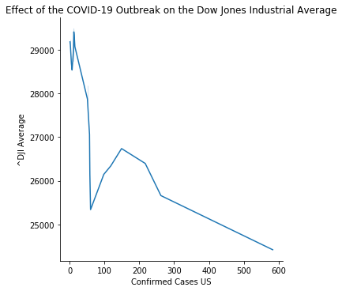

```python
# Visualize relationship between ^DJI and COVID-19 datasets
plot1 = sns.relplot(x="Confirmed Cases US", y="^DJI Average", kind="line", data=df)
axes = plot1.axes.flatten()
axes[0].set_title("Effect of the COVID-19 Outbreak on the Dow Jones Industrial Average")
```

## Here we see the negative impact of the COVID-19 outbreak in Italy on the Dow Jones Titans 30 Index

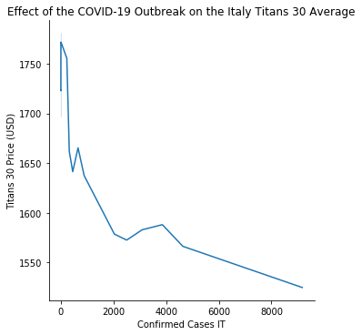

```python
plot1 = sns.relplot(x="Confirmed Cases IT", y="Titans 30 Price (USD)", kind="line", data=df)
axes = plot1.axes.flatten()
axes[0].set_title("Effect of the COVID-19 Outbreak on the Italy Titans 30 Average")
```

## Lastly we see the interesting effect of the COVID-19 outbreak in China on the SSE.

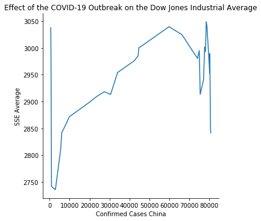

```python
plot1 = sns.relplot(x="Confirmed Cases China", y="SSE Average", kind="line", data=df)
axes = plot1.axes.flatten()
axes[0].set_title("Effect of the COVID-19 Outbreak on the Dow Jones Industrial Average")
```

### This plot shows the linear relationship between the COVID-19 outbreak in the US and the DJI Average

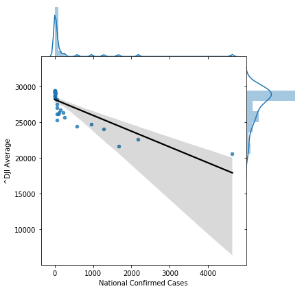

```python
sns.jointplot(
    x='National Confirmed Cases',
    y='^DJI Average',
    data=result_US_DJI,
    stat_func=None,
    kind="reg",
    ratio=4,
    space=0,
    scatter_kws={
        's': 20,},
    line_kws={
        'color': 'black'
    }
);
```

### This plot shows the linear relationship between the COVID-19 outbreak in Italy and the Titans 30 Average

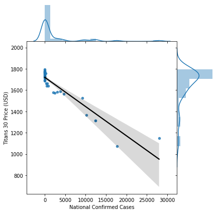

```python
sns.jointplot(
    x='National Confirmed Cases',
    y='Titans 30 Price (USD)',
    data=result_IT,
    stat_func=None,
    kind="reg",
    ratio=4,
    space=0,
    scatter_kws={
        's': 20,},
    line_kws={
        'color': 'black'
    }
);
```

### This plot shows the linear relationship between the COVID-19 outbreak in China and the SSE Average

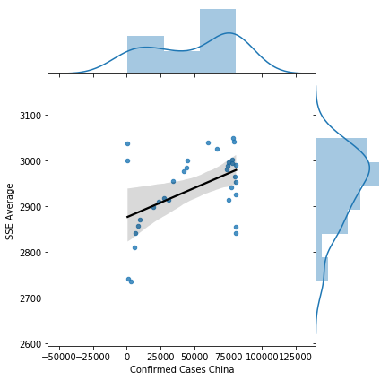

```python
sns.jointplot(
    x='Confirmed Cases China',
    y='SSE Average',
    data=df,
    stat_func=None,
    kind="reg",
    ratio=4,
    space=0,
    scatter_kws={
        's': 20,},
    line_kws={
        'color': 'black'
    }
);
```

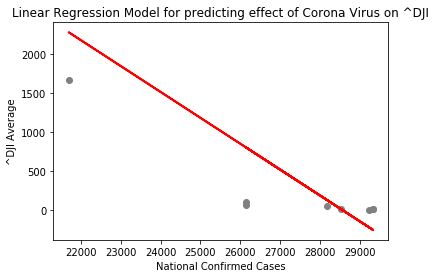

|  | Actual | Predicted |
| --- | --- | --- |
| 0 | 51 | 123.626737 |
| 1 | 13 | -257.564661 |
| 2 | 58 | 799.232202 |
| 3 | 12 | -258.613854 |
| 4 | 98 | 799.034810 |
| 5 | 5 | 5.043992 |
| 6 | 1663 | 2277.418120 |
| 7 | 1 | -222.577314 |

```python
# Next we move to the predictive modeling portion of this project. First let's import our libraries
from sklearn.model_selection import train_test_split
from sklearn.linear_model import LinearRegression
from sklearn import metrics

# We will begin by first using a linear regression model (it is obvious that the models do not have strictly linear correlations so we are not doing this for accuracy just out of curiosity)
y_US=result_US_DJI["National Confirmed Cases"].values.reshape(-1,1)
x_US=result_US_DJI["^DJI Average"].values.reshape(-1,1)
x_train_US,x_test_US,y_train_US,y_test_US=train_test_split(x_US,y_US,test_size=0.2)
x_train_US = np.asarray(x_train_US)
x_test_US = np.asarray(x_test_US)
y_train_US = np.asarray(y_train_US)
y_test_US = np.asarray(y_test_US)
regressor = LinearRegression()
regressor.fit(x_train_US, y_train_US)


y_pred_US = regressor.predict(x_test_US)
plt.scatter(x_test_US, y_test_US,  color='gray')
plt.plot(x_test_US, y_pred_US, color='red', linewidth=2)
plt.title("Linear Regression Model for predicting effect of Corona Virus on ^DJI")
plt.xlabel("National Confirmed Cases")
plt.ylabel("^DJI Average")
plt.show()

# As you can see our results are awful
df = pd.DataFrame({'Actual': y_test_US.flatten(), 'Predicted': y_pred_US.flatten()})
df
```

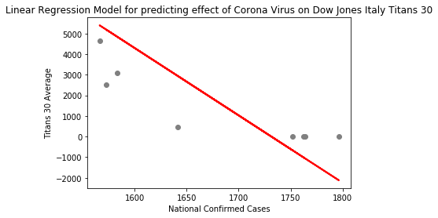

|  | Actual | Predicted |
| --- | --- | --- |
| 0 | 453 | 2944.862393 |
| 1 | 3 | -1060.995809 |
| 2 | 3089 | 4853.472544 |
| 3 | 2502 | 5191.843820 |
| 4 | 3 | -673.912147 |
| 5 | 4636 | 5396.828158 |
| 6 | 3 | -2119.591161 |
| 7 | 2 | -1002.148630 |

```python
# Let's take a look at how bad they are for Italy
y_IT=result_IT["National Confirmed Cases"].values.reshape(-1,1)
x_IT=result_IT["Titans 30 Price (USD)"].values.reshape(-1,1)
x_train_IT,x_test_IT,y_train_IT,y_test_IT=train_test_split(x_IT,y_IT,test_size=0.2)

regressor = LinearRegression()
regressor.fit(x_train_IT, y_train_IT)

y_pred_IT = regressor.predict(x_test_IT)
plt.scatter(x_test_IT, y_test_IT,  color='gray')
plt.plot(x_test_IT, y_pred_IT, color='red', linewidth=2)
plt.title("Linear Regression Model for predicting effect of Corona Virus on Dow Jones Italy Titans 30")
plt.xlabel("National Confirmed Cases")
plt.ylabel("Titans 30 Average")
plt.show()

# As you can see our results are again awful
df = pd.DataFrame({'Actual': y_test_IT.flatten(), 'Predicted': y_pred_IT.flatten()})
df
```

### These relationships are not simply linear so it is impossible to create a truly accurate model using only linear regression

# In conclusion we see that the COVID-19 outbreak had an extremely negative impact on both the United States Dow Jones Industrial Average and the Italy Dow Jones Titans 30 Index. However, in China we see that the COVID-19 outbreak actually had a positive impact on the SSE Average.